# Solutions for the Scoot Data Set

```python
import pandas as pd
import numpy as np
from pandasql import sqldf
import matplotlib.pyplot as plt


#Read in the data frame
scoot_df = pd.read_csv("Data/Scoot_Data/Ride_Customer_Info.csv")

scoot_df.head()
```

|  | ride_id | trip_time | trip_dist | plan_id | hr_start | dow | time_slot | batt_perc | dist_h | price | start_location_id | lat | lng | end_location_id | lat.1 | lng.1 |
| --- | --- | --- | --- | --- | --- | --- | --- | --- | --- | --- | --- | --- | --- | --- | --- | --- |
| 0 | 211870 | 11.336693 | 3.0 | Pro | 0 | 1 | 0 | 0.361143 | 0.287168 | 2.0 | 104 | 37.794700 | -122.410960 | 56 | 37.771578 | -122.442181 |
| 1 | 211871 | 36.616880 | 2.0 | Pro | 0 | 1 | 0 | 0.979784 | 0.080456 | 4.0 | 21 | 37.775606 | -122.416976 | 42 | 37.749810 | -122.431790 |
| 2 | 211885 | 17.900736 | 3.6 | Go | 4 | 1 | 0 | 0.500000 | 0.019225 | 3.0 | 90 | 37.784174 | -122.480460 | 9 | 37.791758 | -122.404929 |
| 3 | 211890 | 15.330679 | 3.2 | Other | 5 | 1 | 1 | 0.897714 | 0.119214 | 3.0 | 97 | 37.804907 | -122.441988 | 26 | 37.791638 | -122.391761 |
| 4 | 211894 | 138.113334 | 5.3 | Other | 6 | 1 | 1 | 0.848000 | 0.030645 | 8.0 | 55 | 37.777440 | -122.464940 | 87 | 37.795342 | -122.398735 |

Use SQL to create a data frame df_travel that has three columns: trip_time, trip_dist, avg_speed (= trip_dist/trip_time).

```python
#Get the three columns
df_travel = sqldf("SELECT trip_time, trip_dist, trip_dist/trip_time AS avg_speed FROM scoot_df")
df_travel.head()
```

|  | trip_time | trip_dist | avg_speed |
| --- | --- | --- | --- |
| 0 | 11.336693 | 3.0 | 0.264627 |
| 1 | 36.616880 | 2.0 | 0.054620 |
| 2 | 17.900736 | 3.6 | 0.201109 |
| 3 | 15.330679 | 3.2 | 0.208732 |
| 4 | 138.113334 | 5.3 | 0.038374 |

The dow column has the following interpretation:

- 0: Monday
- 1: Tuesday
- 2: Wednesday
- 3: Thursday
- 4 Friday
- 5: Saturday
- 6: Sunday

What was the average price of rides that took place on the weekend and started after noon (hr_start >= 12).

```python
sqldf("SELECT AVG(price) FROM scoot_df WHERE (dow = 5 OR dow =6) AND hr_start >=12")
```

|  | AVG(price) |
| --- | --- |
| 0 | 3.876614 |

How many trips lasted longer than 30 minutes?

```python
#Find the number of trips that were longer than 30 minutes
sqldf("SELECT COUNT(*) countTrips FROM scoot_df WHERE trip_time>=30")
```

|  | countTrips |
| --- | --- |
| 0 | 4238 |

Write a query to get the number of rides starting in each hour.

```python
#Get the number of rides starting in each hour
Count_TOD = sqldf("SELECT hr_start,COUNT(*) num_rides FROM scoot_df GROUP BY hr_start")
Count_TOD
```

|  | hr_start | num_rides |
| --- | --- | --- |
| 0 | 0 | 113 |
| 1 | 1 | 55 |
| 2 | 2 | 43 |
| 3 | 3 | 13 |
| 4 | 4 | 27 |
| 5 | 5 | 126 |
| 6 | 6 | 355 |
| 7 | 7 | 1101 |
| 8 | 8 | 1104 |
| 9 | 9 | 663 |
| 10 | 10 | 513 |
| 11 | 11 | 596 |
| 12 | 12 | 631 |
| 13 | 13 | 693 |
| 14 | 14 | 682 |
| 15 | 15 | 743 |
| 16 | 16 | 1010 |
| 17 | 17 | 1588 |
| 18 | 18 | 1192 |
| 19 | 19 | 930 |
| 20 | 20 | 597 |
| 21 | 21 | 460 |
| 22 | 22 | 368 |
| 23 | 23 | 186 |

Create a line plot - where the x-axis is the hour of the day and the y-axis is the number of rides. Give an appropriate title and appropriate axes labels.

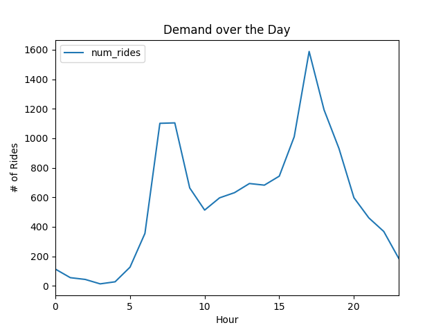

```python
%matplotlib notebook

fig, ax = plt.subplots()

Count_TOD.plot(kind="line", x = "hr_start", y = "num_rides", ax=ax)

ax.set(title = "Demand over the Day", xlabel = "Hour", ylabel = "# of Rides")
```

Write a query to get the number of rides starting in each hour by plan.

```python
Count_TOD_plan = sqldf("SELECT plan_id,hr_start,COUNT(*) num_rides FROM scoot_df GROUP BY hr_start, plan_id")
Count_TOD_plan.head(10)
```

|  | plan_id | hr_start | num_rides |
| --- | --- | --- | --- |
| 0 | Go | 0 | 25 |
| 1 | Intro_Pro | 0 | 29 |
| 2 | Other | 0 | 27 |
| 3 | Pro | 0 | 32 |
| 4 | Go | 1 | 16 |
| 5 | Intro_Pro | 1 | 17 |
| 6 | Other | 1 | 8 |
| 7 | Pro | 1 | 14 |
| 8 | Go | 2 | 2 |
| 9 | Intro_Pro | 2 | 7 |

Write a query to find the average price of each ride that has an initial battery charge of more than 50$\%$ originating at every hour of the day. Compare this with rides where the initial charge was below 50$\%$. This helps answer the question: Are scooters with less charge, less valuable?

```python
#Find the times that are the most valuable for charged scooter (>50% charge)
charged_prices = sqldf("SELECT hr_start,AVG(price) AS avg_price_charged FROM scoot_df WHERE batt_perc > 0.5 GROUP BY hr_start")

#Find the times that are the most valuable for not very charged scooter (<=50% charge)
uncharged_prices = sqldf("SELECT hr_start,AVG(price) AS avg_price_uncharged FROM scoot_df WHERE batt_perc <= 0.5 GROUP BY hr_start")

#tack on the uncharged prices
charged_prices['avg_price_uncharged'] = uncharged_prices.iloc[:,1]

#Make new column that is the different
charged_prices['diff'] = charged_prices['avg_price_charged'] - charged_prices['avg_price_uncharged']

#Find the average difference
np.mean(charged_prices['diff'])
```

```
0.7006648202905144
```